# Module 2 - Potential Outcomes (Answer Key)

ECON 526/593E

# Potential Outcomes and Randomization

**Click for Submission Instructions & Data**

Prepare your answers in R Markdown. Your submission should contain the exact same headings shown below along with your text and graphs, where appropriate, addressing all questions. When you knit your R Markdown script, use the following file naming convention for the html and Rmd documents you generate: lastname_module_N_homework.html (.Rmd) (replace "lastname" with your last name and "N" with the module number). Email your documents as attachments to ajc0056@mix.wvu.edu with the subject line "ECON 593 lastname Homework Module N". You can download the data for this module here (hint[^1]). It will specify when/where packages are needed.

The Module 1 homework contained a tricky question about regression parameters and causality. The question was tricky because the arrows on DAGs represent causal relationships, but we need a better understanding of what causation means in order to fully answer that question. Module 2 develops a framework for understanding causation and how causation relates to econometric analysis. *The Mixtape* chapter also discusses the importance of randomization in causal inference.

This homework explores randomization by writing R code to replicate the results in an economics paper, "A Randomized Assessment of Online Learning" by William T. Alpert, Kenneth A. Couch and Oskar R. Harmon in the *American Economic Review*. This paper uses explicit randomization of students into economics classes with different delivery methods (in class, blended, on-line only) to assess the causal effect of on-line course delivery on student learning. The paper is available on eCampus in the Module 2 folder. You should first read the paper before completing this homework. The data file for this paper has been provided to you for download.

## Question 1

Summarize the main research question in the paper, the application analyzed and why this causal inference approach is appropriate for the research question. (**2 Points**)

## Question 2

Read in the dataset `alpert_aer.csv`.

Describe the data analyzed, including general structure of the data set, sources, and the nature of the data. Discuss why might this data set be appropriate for this causal inference method. Generate summary statistics for all of the main variables used in the analysis using `stargazer`. (**2 points**)

```r
library("stargazer")
aer <- read.csv("alpert_aer.csv", stringsAsFactors = FALSE)

stargazer(aer, type = "text")
```

```
##
## ============================================================================
## Statistic              N   Mean   St. Dev.   Min   Pctl(25) Pctl(75)   Max
## ----------------------------------------------------------------------------
## gpa                   525  3.096   0.605    0.191   2.771    3.545    4.000
## cum_total_crds        632 33.638   23.762   0.000   16.000   44.000  135.000
## gender                670  0.558   0.497      0       0        1        1
## asian                 500  0.184   0.388    0.000   0.000    0.000    1.000
## black                 500  0.084   0.278    0.000   0.000    0.000    1.000
## hawaiian              500  0.008   0.089    0.000   0.000    0.000    1.000
## hispanic              500  0.022   0.147    0.000   0.000    0.000    1.000
## unknown               500  0.008   0.089    0.000   0.000    0.000    1.000
## white                 500  0.694   0.461    0.000   0.000    1.000    1.000
## ethnic_dummy          507  0.316   0.465    0.000   0.000    1.000    1.000
## format_ol             670  0.258   0.438      0       0        1        1
## format_blended        670  0.255   0.436      0       0        1        1
## sat_math_NEW          611 621.809  74.139  420.000 570.000  670.000  800.000
## sat_verbal_NEW        612 582.688  76.698  360.000 530.000  630.000  800.000
## enroll_count          519  2.441   0.781    1.000   2.000    3.000    3.000
## format_f2f_v_ol       498  0.345   0.476    0.000   0.000    1.000    1.000
## format_f2f_v_blended  498  0.345   0.476    0.000   0.000    1.000    1.000
## format_combined_v_f2f 670  0.487   0.500      0       0        1        1
## falsexam              670 37.521   39.189     0       0       78.3     97
## experiment1           576  0.738   0.440    0.000   0.000    1.000    1.000
## ----------------------------------------------------------------------------
```

## Question 3

Describe the causal inference method used in this paper. Discuss the assumptions underlying the causal inference method used in the empirical analysis. Discuss threats to validity of the results in terms of causal inference. (**2 points**)

## Question 4

Visualize the data. (**2 points**)

Limit the dataset to only the observations used in column 1 of Panel A in Table 1 in the paper (hint[^2]).

Generate a scatter plot of student GPA vs Final Exam Score. Color the observations who were online one color and everyone else another color. Use the `scales` package and make the opacity .3. Make the online students a starburst shaped symbol and all other students a filled-in square. Make a legend in the lower right corner of the graph to explain the colors and shapes. Label the axes.

Generate a second graph using the `density` function in R. Plot the densities of the final scores for all three learning types (hint[^3]). Make each one a different color. Make a legend in the top left corner to explain the colors. Label the axes.

```r
table(aer$enroll_count)
table(aer$enroll_count, useNA = "ifany")
```

```
##
##   1   2   3
##  94 102 323
##
##    1    2    3 <NA>
##   94  102  323  151
```

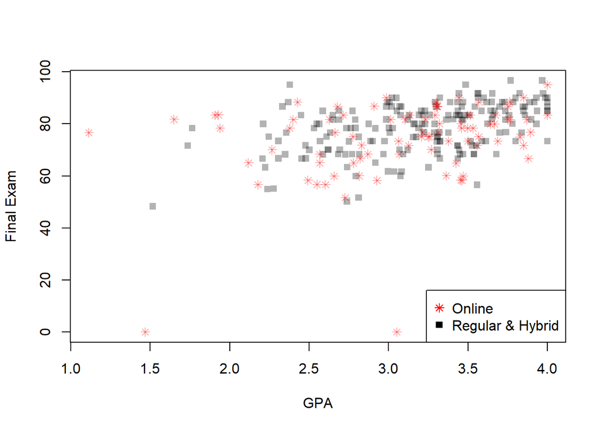

```r
library("scales")

#enroll count could either be missing, 1, 2, or 3.  Making sure it is not missing and ==3.
lim <- !is.na(aer$enroll_count) & aer$enroll_count == 3

plot(aer$gpa[lim], aer$falsexam[lim],
     col = alpha(ifelse(aer$format_ol[lim] == 1, "red", "black"), .3),
     pch = ifelse(aer$format_ol[lim] == 1, 8, 15),
     xlab = "GPA", ylab = "Final Exam")
legend("bottomright", pch = c(8, 15),
       legend = c("Online", "Regular & Hybrid"),
       col = c("red", "black"))
```

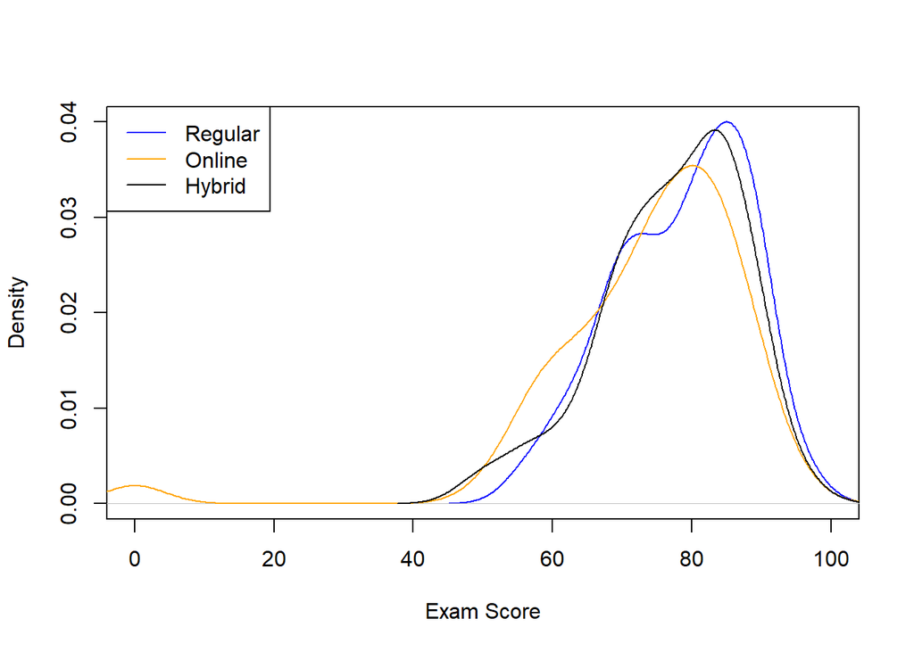

```r
#only plot the exam scores
plot(density(aer$falsexam[lim & aer$format_ol == 0 & aer$format_blended == 0]),
     xlim = c(0, 100), col = "blue", main = "", xlab = "Exam Score", ylab = "Density")
lines(density(aer$falsexam[lim & aer$format_ol == 1 & aer$format_blended == 0]),
     xlim = c(0, 100), col = "orange")
lines(density(aer$falsexam[lim & aer$format_ol == 0 & aer$format_blended == 1]),
     xlim = c(0, 100), col = "black")
legend("topleft", col = c("blue", "orange", "black"), lty = 1,
       legend = c("Regular", "Online", "Hybrid"))
```

## Question 5

Replicate the main results reported in the paper on Table 1. Make sure that you follow the guidelines for replicable research (**2 points**)

Replicate Table B.1 in the online Appendix [here](https://assets.aeaweb.org/asset-server/articles-attachments/aer/app/10605/P2016_1057_app.pdf#page=5).

Recall the plots generated above. Are there any artifacts or outliers in the data that could be driving the results? Remove anything that sticks out to you and rerun the analysis.

```r
reg1 <- lm(falsexam ~ format_ol + format_blended, data = aer[lim,])
reg2 <- lm(falsexam ~ format_ol + format_blended +
             gpa + cum_total_crds + sat_math_NEW + sat_verbal_NEW, data = aer[lim,])
reg3 <- lm(falsexam ~ format_ol + format_blended +
             gpa + cum_total_crds + sat_math_NEW + sat_verbal_NEW +
             gender + asian + black + hispanic + hawaiian + unknown, data = aer[lim,])
stargazer(reg1, reg2, reg3, type = "text", omit.stat = c("ser", "f"))
```

```
##
## ============================================
##                     Dependent variable:
##                -----------------------------
##                          falsexam
##                   (1)       (2)       (3)
## --------------------------------------------
## format_ol      -4.912*** -5.201*** -4.232***
##                 (1.588)   (1.596)   (1.578)
##
## format_blended  -1.454    -1.703    -0.996
##                 (1.525)   (1.524)   (1.511)
##
## gpa                      7.702***  8.580***
##                           (1.221)   (1.238)
##
## cum_total_crds            -0.045    -0.048
##                           (0.033)   (0.033)
##
## sat_math_NEW             0.035***   0.025**
##                           (0.010)   (0.010)
##
## sat_verbal_NEW            -0.011    -0.007
##                           (0.009)   (0.010)
##
## gender                             4.644***
##                                     (1.358)
##
## asian                               -0.973
##                                     (1.717)
##
## black                               -3.335
##                                     (2.575)
##
## hispanic                             1.043
##                                     (4.734)
##
## hawaiian                             6.056
##                                     (5.509)
##
## unknown                             -10.951
##                                     (9.555)
##
## Constant       78.547*** 41.168*** 39.925***
##                 (1.052)   (7.429)   (8.433)
##
## --------------------------------------------
## Observations      323       265       215
## R2               0.030     0.234     0.345
## Adjusted R2      0.024     0.216     0.307
## ============================================
## Note:            *p<0.1; **p<0.05; ***p<0.01
```

```r
#removing the two 0's from the data as well
lim <- lim & aer$falsexam > 0
reg1 <- lm(falsexam ~ format_ol + format_blended, data = aer[lim,])
reg2 <- lm(falsexam ~ format_ol + format_blended +
             gpa + cum_total_crds + sat_math_NEW + sat_verbal_NEW, data = aer[lim,])
reg3 <- lm(falsexam ~ format_ol + format_blended +
             gpa + cum_total_crds + sat_math_NEW + sat_verbal_NEW +
             gender + asian + black + hispanic + hawaiian + unknown, data = aer[lim,])
stargazer(reg1, reg2, reg3, type = "text", omit.stat = c("ser", "f"))
```

```
##
## ============================================
##                     Dependent variable:
##                -----------------------------
##                          falsexam
##                   (1)       (2)       (3)
## --------------------------------------------
## format_ol      -3.311**  -3.729*** -3.625**
##                 (1.378)   (1.314)   (1.413)
##
## format_blended  -1.454    -1.732    -0.953
##                 (1.315)   (1.248)   (1.351)
##
## gpa                      6.204***  6.630***
##                           (1.020)   (1.139)
##
## cum_total_crds            -0.019    -0.036
##                           (0.027)   (0.029)
##
## sat_math_NEW             0.034***  0.026***
##                           (0.008)   (0.009)
##
## sat_verbal_NEW            -0.005    -0.004
##                           (0.008)   (0.009)
##
## gender                             3.636***
##                                     (1.221)
##
## asian                               -1.677
##                                     (1.538)
##
## black                               -3.838*
##                                     (2.302)
##
## hispanic                            -0.154
##                                     (4.234)
##
## hawaiian                             5.256
##                                     (4.925)
##
## unknown                            -15.073*
##                                     (8.559)
##
## Constant       78.547*** 41.879*** 43.493***
##                 (0.908)   (6.092)   (7.553)
##
## --------------------------------------------
## Observations      321       263       214
## R2               0.018     0.234     0.322
## Adjusted R2      0.012     0.216     0.281
## ============================================
## Note:            *p<0.1; **p<0.05; ***p<0.01
```

## Question 6

Discuss the results you generate. What is the interpretation of the causal parameter of interest? Place the causal effect in the context of the data. (**2 points**)

## Question 7

Compare your results and this application to the example in *The Mixtape* chapter for randomization. Is this application better or worse than the one in the chapter? How does this application of randomiztion, and these results, differ? For example, discuss differences in the strength of assumptions, effect size, etc. (**2 points**)

## Question 8

Do you believe the results you replicated are credibly causal? Are the signs and magnitudes plausible? (**2 points**)

[^1]: When reading the data, you can just do something like `read.csv("https://alexcardazzi.github.io/teaching/econ-593e/alpert_aer.csv")` instead of downloading the data. This will help you avoid messing too much with working directories and ensure the files are the same for everyone. Keep this in mind for future HWs.
[^2]: This uses the variable called `enroll_count`. Tabulate this variable, and limiting the data should become somewhat more clear.
[^3]: More information [here](https://www.dummies.com/programming/r/how-to-add-lines-to-a-plot-in-r/) on how to add lines to a plot.